# Ekman Transport Calculations

EE Holmes

11/9/2020

This report confirms that I am able to replicate the [upwelling calculations](https://oceanview.pfeg.noaa.gov/products/upwelling/bakun) provided by the Environmental Research Division at the Southwest Fisheries Science Center.

# Get the data

Get pressure, wind, and Ekman Transport from the Coastwatch ERDDAP server. This gets the data for the current month and has all the needed parameters. Current FNMOC grid resolution is 1 degree while older resolution was 2.5 degree and later interpolated to 1 degree.

Get data from https://coastwatch.pfeg.noaa.gov/erddap/griddap/erdlasFnTransMon

```r
dates <- c("2020-11-01T00:00:00Z", "2020-11-02T06:00:00Z")
dat <- getdata("erdlasFnTransMon", date=dates)
```

```
## data read from /Users/eli.holmes/Documents/GitHub/SardineForecast/inst/extdata/get_satellite_data/Replicate_EMT/erdlasFnTransMon-7-15-70-78-2020-11-01-2020-11-02.csv
## data erdlasFnTransMon date 2020-11-01T00:00:00Z-2020-11-02T06:00:00Z, latitude 7-15, longitude 70-78
```

```r
cat(colnames(dat))
```

```
## time latitude longitude P_msl u v uv_mag taux tauy curl ektrx ektry
```

# Calculations of wind from FNMOC winds

Schwing, F. B., O’Farrell, M., Steger, J., and Baltz, K., 1996: Coastal Upwelling Indices, West Coast of North America 1946 - 1995, NOAA Technical Memorandum NMFS-SWFSC-231

Schwing et al 1996 gives the calculations for computing the wind vector from the pressures reported by FNMOC. First the pressure differential in the $y$ (north-south) and $x$ (east-west) directions is computed. $y$ is the latitude center of the box. $x$ is the longitude center of the box. $P$ is in Pascals. Note the the pressure reported by FNMOC must be multiplied by 100 to get Pascals. $h$ is the resolution of the grid in radians ($ = $ 1 degree / 180 degree). Equation 1 in Schwing et al 1996:

$$\begin{equation}
\frac{\Delta P}{\Delta x} = (P_{x+h,y}-P_{x-h,y})/2h \quad \quad
\frac{\Delta P}{\Delta y} = (P_{x,y+h}-P_{x,y-h})/2h
\end{equation}$$
The east ($\vec{u}_g$) and north ($\vec{v}_g$) components of the geostrophic wind are (Equation 2 in Schwing et al 1996):

$$\begin{align}
&\vec{u}_g = -\frac{1}{f \, p_a \, R}\frac{\Delta P}{\Delta y}\\
&\vec{v}_g = \frac{1}{f \, p_a \, R \, cos(\pi y/180)}\frac{\Delta P}{\Delta x}
\end{align}$$
In the equation, $p_a = 1.22 \, kg/m^3$ and $R$ is the radius of the earth in meters $= 6371000 \, m$. $f$ is the Coriolis parameters and is $2 \Omega sin(\pi y/180)$, where $\Omega - 7.272205 \times 10^{-5}$ and $y$ is the latitude of the center of the grid cell in degrees (and $\pi y/180$ is the latitude in radians). Positive $\vec{u}$ is wind blowing west to east. Positive $\vec{v}$ is wind blowing south to north (in the northern hemisphere). Notice the the east-west geostrophic wind is associated with the north-south pressure differential while the north-south wind is associated with the east-west differential.

$$\begin{align}
\vec{u} = 0.7 (cos(\alpha) \, u_g - sin(\alpha) \, v_g)\\
\vec{v} = 0.7 (sin(\alpha) \, u_g + cos(\alpha) \, v_g)
\end{align}$$
The `getwindfromP()` function at the end of this report shows the R code for these calculations.

```r
wind1 <- getwindfromP(dat)
```

## Compare to wind numbers reported by ERD

Show that this is the same as what is reported by SWFSC-ERD.

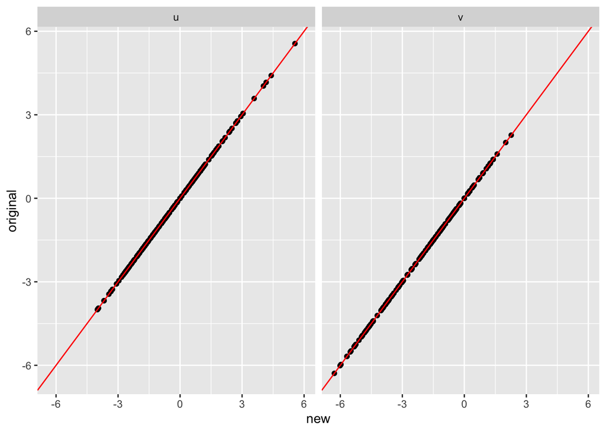

# Calculations of Ekman Transport

Wind stress (Newtons/$m^2$) and wind stress broken into its $x$ (east-west) and $y$ (north-south) components is (Equation 3 in Schwing et al 1996):

$$\begin{gather}
\vec{\tau} = p_a \, C_d \, |\vec{w}| \, \vec{w}\\
\tau_x = p_a \, C_d \, |\vec{w}| \, \vec{u} \quad \quad \tau_y = p_a \, C_d \, w \, \vec{v}
\end{gather}$$
where $C_d$ is the coefficient of drag and $|\vec{w}|$ is the wind speed (in m/s) and $\vec{w}$ is the wind vector. $C_d$ is the empirical drag coefficient. It is a non-linear drag coefficient based on Large and Pond (1981) and modified for low wind speeds as in Trenberth et al. (1990), per discussion on the [ERD upwelling page](https://oceanview.pfeg.noaa.gov/products/upwelling/bakun).

$$\begin{equation}
C_d =
\begin{cases}
2.18 \times 10^-3,& \text{if } |\vec{w}| < 1\\
(0.62 + \frac{1.56}{|\vec{w}|}) \times 10^-3& \text{if } 1 < |\vec{w}| < 3\\
1.14 \times 10^-3& \text{if } 3 \geq |\vec{w}| < 10\\
(0.49 + 0.065 |\vec{w}|) \times 10^-3& \text{if } 10 \geq |\vec{w}|
\end{cases}
\end{equation}$$

Ekman Mass Transport (EMT kg/ms) is perpendicular (rotated 90 degrees clockwise) to wind stress. The EMT in the $x$ and $y$ directions is (Equation 4 in in Schwing et al 1996):
$$\begin{equation}
EMT_y = - \tau_x/f \quad\quad EMT_x = \tau_y/f
\end{equation}$$

The `getEMT()` and `Cd()` functions shows how to compute these. `coast_angle` is added here for the upwelling index discussed below.

```r
wind1 <- getEMT(wind1, coast_angle=158)
```

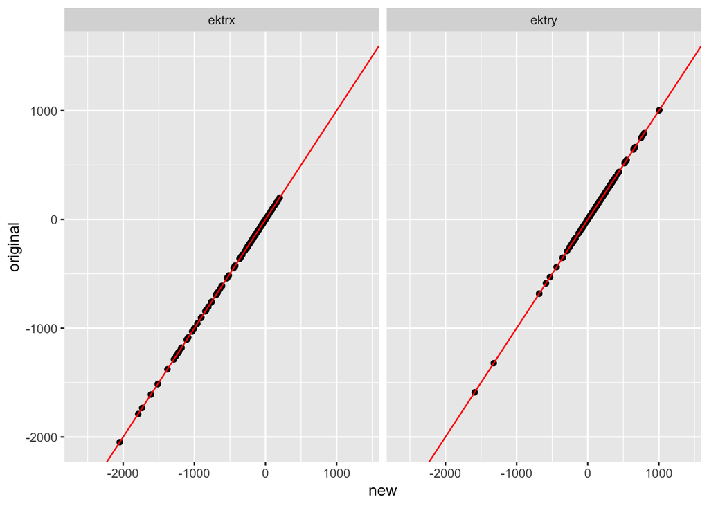

# Upwelling index

[ERD’s Bakun upwelling index](https://oceanview.pfeg.noaa.gov/products/upwelling/bakun) is the EMT that is perpendicular and away from the coast. This is computed by finding the EMT vector that is perpendicular to the coast and defining a positive vector as away from the coast and a negative vector as toward the coast. ERD then divides this value by 10. The coast angle is defined as the degrees rotation clockwise away from north-south with land to the west (see figure). The coast angle for the SW coast of India is 158 degrees.

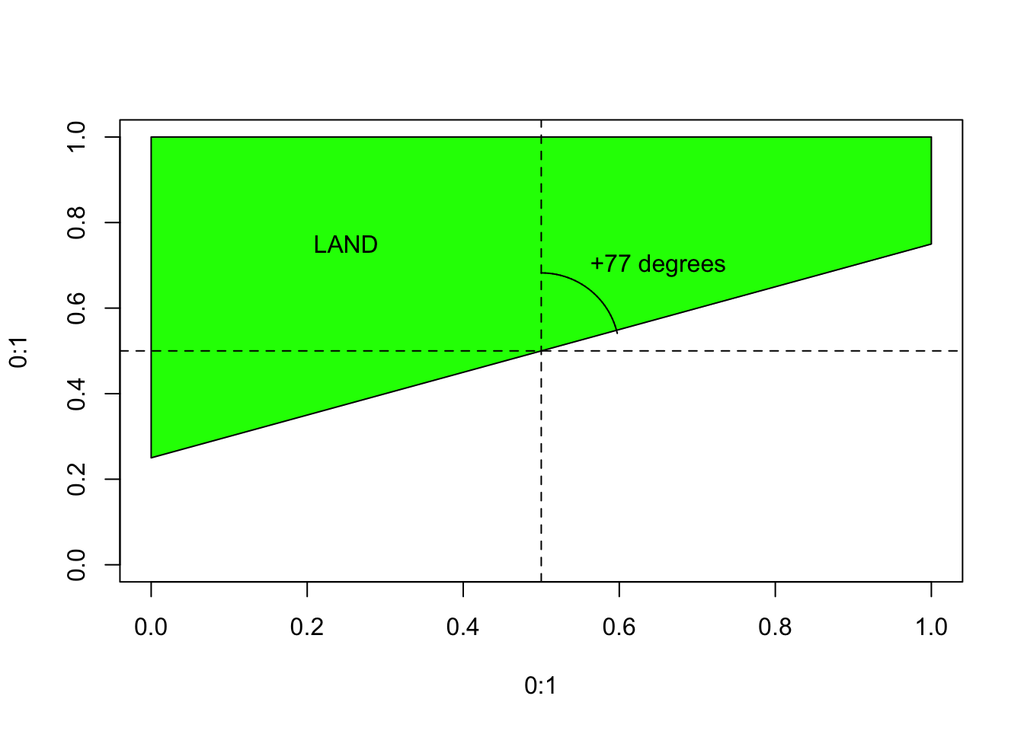

The equation to rotate the EMT vector is the following with the coast angle $\theta$ in degrees.
$$\begin{align}
&\alpha = (360 - \theta) \pi / 180 \\
&upi = \frac{EMT_x cos(\alpha) + EMT_y sin(\alpha)}{10}
\end{align}$$

The `upwell()` function shows how to compute this from the coast angle and the EMT in the $x$ and $y$ directions. Here the upwelling index using the data from the ERD EMT values is added to the data frame.

```r
wind1$upi_orig <- upwell(wind1$ektrx_orig, wind1$ektry_orig, 158)
```

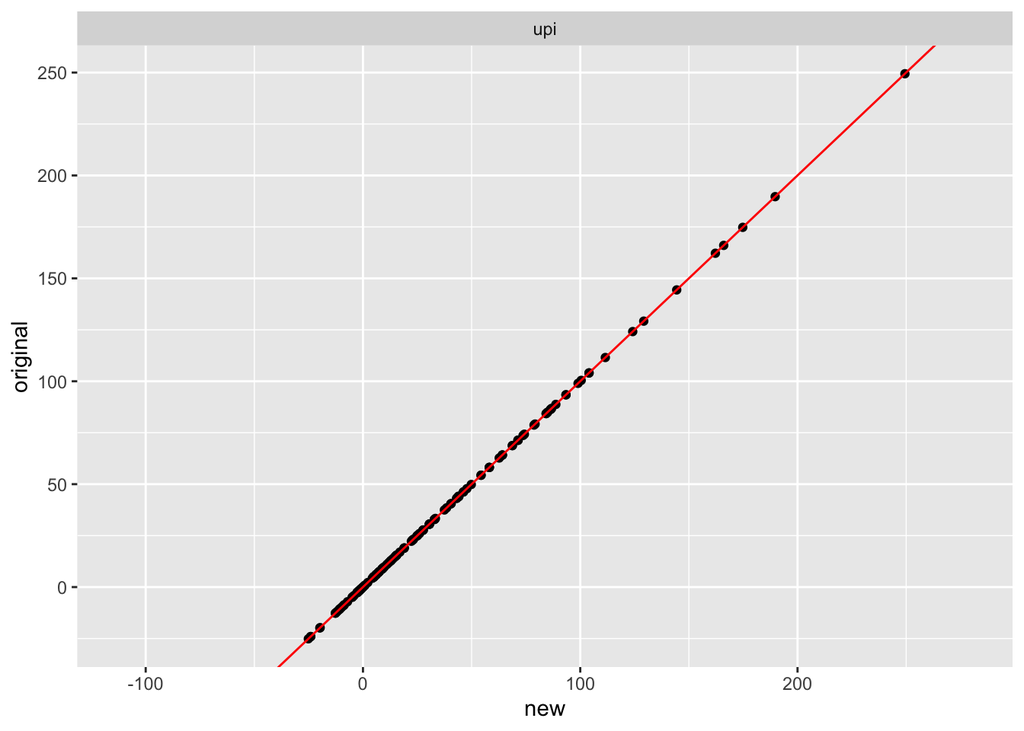

# Functions in R

```
upwell <-  function (ektrx, ektry, coast_angle)
{
    pi <- 3.1415927
    degtorad <- pi/180
    alpha <- (360 - coast_angle) * degtorad
    s1 <- cos(alpha)
    t1 <- sin(alpha)
    s2 <- -1 * t1
    t2 <- s1
    perp <- (s1 * ektrx) + (t1 * ektry)
    para <- (s2 * ektrx) + (t2 * ektry)
    return(perp/10)
}
```

```
Cd <-  function (wind.speed)
{
    wind.orig <- wind.speed
    wind.speed[is.na(wind.speed)] <- -Inf
    Cd <- wind.orig
    Cd[wind.speed <= 1] <- 2.18
    Cd[wind.speed < 3 & wind.speed > 1] <- 0.62 + 1.56/wind.speed[wind.speed <
        3 & wind.speed > 1]
    Cd[wind.speed >= 3 & wind.speed < 10] <- 1.14
    Cd[wind.speed >= 10] <- 0.49 + 0.065 * wind.speed[wind.speed >=
        10]
    Cd[is.na(wind.orig)] <- NA
    return(Cd * 0.001)
}
```

```
EMTperp <-  function (ektrx, ektry, coast_angle)
{
    pi <- 3.1415927
    degtorad <- pi/180
    alpha <- (180 - coast_angle) * degtorad
    s1 <- cos(alpha)
    t1 <- sin(alpha)
    s2 <- -1 * t1
    t2 <- s1
    perp <- (s1 * ektrx) + (t1 * ektry)
    para <- (s2 * ektrx) + (t2 * ektry)
    return(list(perp = perp, para = para))
}
```

```
getEMT <-  function (dat, coast_angle = NULL)
{
    if (!any(colnames(dat) == "u"))
        stop("need u in data")
    if (!any(colnames(dat) == "v"))
        stop("need v in data")
    for (i in c("uv_mag", "tau", "taux", "tauy", "EMT", "ektrx",
        "ektry", "upi")) if (any(colnames(dat) == i)) {
        warning(paste0(i, " is already in data. Changing to ",
            i, "_orig\n"))
        colnames(dat)[colnames(dat) == i] <- paste0(i, "_orig")
    }
    pa <- 1.22
    omega <- 7.272205e-05
    f <- 2 * omega * sin(pi * dat$latitude/180)
    uv_mag <- sqrt(dat$u^2 + dat$v^2)
    tau <- pa * Cd(uv_mag) * uv_mag * uv_mag
    tauy <- pa * Cd(uv_mag) * uv_mag * dat$v
    taux <- pa * Cd(uv_mag) * uv_mag * dat$u
    EMT <- tau/f
    EMTy <- -1 * taux/f
    EMTx <- tauy/f
    dat$uv_mag <- uv_mag
    dat$tau <- tau
    dat$taux <- taux
    dat$tauy <- tauy
    dat$EMT <- EMT
    dat$ektrx <- EMTx
    dat$ektry <- EMTy
    if (!missing(coast_angle)) {
        dat$EMTperp <- EMTperp(dat$ektrx, dat$ektry, coast_angle)$perp
        dat$upi <- upwell(dat$ektrx, dat$ektry, coast_angle)
    }
    return(dat)
}
```

```
getwindfromP <-  function (dat)
{
    if (is.null(attr(dat, "resolution")))
        stop("need resolution in the data.frame")
    if (!any(c("P_msl", "p_msl") %in% colnames(dat)))
        stop("need P_msl or p_msl (pressure) in data")
    for (i in c("u", "v", "P")) if (any(colnames(dat) == i)) {
        warning(paste0(i, " is already in data. Changing to ",
            i, "_orig", "\n"))
        colnames(dat)[colnames(dat) == i] <- paste0(i, "_orig")
    }
    res <- attr(dat, "resolution")
    lons <- sort(unique(dat$longitude))
    lats <- sort(unique(dat$latitude))
    dat$ug <- NA
    dat$vg <- NA
    dat$P <- 100 * dat[, tolower(colnames(dat)) == "p_msl"]
    h <- pi * res/180
    pa <- 1.22
    omega <- 7.272205e-05
    f <- 2 * omega * sin(pi * dat$latitude/180)
    R <- 6371 * 1000
    if (length(lats) > 2)
        for (lat in (min(lats) + res):(max(lats) - res)) {
            dPdlat <- (dat$P[dat$latitude == (lat + res)] - dat$P[dat$latitude ==
                (lat - res)])/(2 * h)
            constant <- (f * pa * R)[dat$latitude == lat]
            ug <- -1 * dPdlat/constant
            dat$ug[dat$latitude == lat] <- ug
        }
    if (length(lons) > 2)
        for (lon in (min(lons) + res):(max(lons) - res)) {
            dPdlon <- (dat$P[dat$longitude == (lon + res)] -
                dat$P[dat$longitude == (lon - res)])/(2 * h)
            constant <- (f * pa * R * cos(pi * dat$latitude/180))[dat$longitude ==
                lon]
            vg <- dPdlon/constant
            dat$vg[dat$longitude == lon] <- vg
        }
    ang <- pi * 30/360
    u <- 0.7 * (cos(ang) * dat$ug - sin(ang) * dat$vg)
    v <- 0.7 * (sin(ang) * dat$ug + cos(ang) * dat$vg)
    dat$u <- u
    dat$v <- v
    return(dat)
}
```

```
getdata <-  function (id, pars = NULL, lat = c(7, 15), lon = c(70, 78), date = NULL,
    altitude = 10)
{
    url <- paste0("https://coastwatch.pfeg.noaa.gov/erddap/info/",
        id, "/index.csv")
    meta <- read.csv(url)
    if (!missing(date) && length(date) == 1)
        date <- c(date, date)
    if (missing(date))
        date <- c(meta$Value[meta$Attribute.Name == "time_coverage_start"],
            meta$Value[meta$Attribute.Name == "time_coverage_end"])
    lat1 <- lat[1]
    lat2 <- lat[2]
    lon1 <- lon[1]
    lon2 <- lon[2]
    dfil <- paste0(id, "-", lat1, "-", lat2, "-", lon1, "-",
        lon2, "-", stringr::str_sub(date[1], 1, 10), "-", stringr::str_sub(date[2],
            1, 10), ".csv")
    dfil <- file.path(here::here(), "inst", "extdata", "get_satellite_data",
        "Replicate_EMT", dfil)
    if (!file.exists(dfil)) {
        if (missing(pars)) {
            pars <- unique(meta$Variable.Name)
            pars <- pars[!(pars %in% c("NC_GLOBAL", "time", "latitude",
                "longitude", "altitude"))]
        }
        alttag <- ifelse("altitude" %in% meta$Variable.Name,
            paste0("[(", altitude, "):1:(", altitude, ")]"),
            "")
        val <- paste0("[(", date[1], "):1:(", date[2], ")]",
            alttag, "[(", lat1, "):1:(", lat2, ")][(", lon1,
            "):1:(", lon2, ")]")
        val2 <- paste0(pars, val, collapse = ",")
        url <- paste0("https://coastwatch.pfeg.noaa.gov/erddap/griddap/",
            id, ".csv?", val2)
        download.file(url, destfile = dfil)
        cat("data saved to", dfil, "\n")
    }
    else {
        cat("data read from", dfil, "\n")
    }
    dat <- read.csv(file = dfil, stringsAsFactors = FALSE)
    dat <- dat[-1, ]
    for (i in 2:ncol(dat)) dat[[i]] <- as.numeric(dat[[i]])
    dat$time <- as.POSIXlt(dat$time, format = "%Y-%m-%dT%H:%M:%OSZ",
        tz = "UTC")
    attr(dat, "resolution") <- as.numeric(meta$Value[meta$Attribute.Name ==
        "geospatial_lat_resolution"])
    cat(paste0("data ", id, " date ", date[1], "-", date[2],
        ", latitude ", lat1, "-", lat2, ", longitude ", lon1,
        "-", lon2), "\n")
    dat
}
```